# Project Report

Andrew Maloney, Sonya Haan, Elaine Oldbear, Connor Hergenreter

5/5/2019

# Background and Questions Raised

Military expenditure has been a hot topic as of late. The United States is estimated to spend $989 billion on their military in 2019 (Amadeo, 2019). If the United States is spending almost a trillion dollars, then how much do other countries spend?

This report will contain findings on how the strongest and weakest militaries compare as well as what determines a military’s strength. If a dataset that contains spending over time is used then conflicts can be tied in to see how much military spending is boosted by this. The other question that will be examined will be on how Mexico’s military spending has changed over time due to their struggle with the drug cartels.

# The Pipeline for Obtaining and Cleaning the Datasets

## Datasets

A dataset containing military expenditure of every existing country from 1949 - 2017 was found at www.sipri.org/databases/milex. The file was an excel workbook that was comprised of 9 sheets all related to military spending. The two sheets used from this set are Current_USD and Share_of_GDP. Current_USD shows military expenditure in US$ in millions as reported for each year. Share_of_GDP displays the military expenditure as a percentage of the country’s GDP at the time.

Three more sets related to military arms will also be used to further examine military spending. These three sets are the Arms Import dataset obtained from https://data.worldbank.org/indicator/MS.MIL.MPRT.KD, the Armed Forces Personel dataset obtained from https://data.worldbank.org/indicator/ms.mil.totl.p1, and the Global Firepower dataset obtained from https://www.kaggle.com/blitzr/gfp2017#GlobalFirePower_multiindex.csv.

The Armed Forces reports the total number of arms imported by each country from 1960 to 2017. Like the Military Expenditure Data set, this was also created by SIPRI. This set was ready to use on download so no cleaning had to be done.

The Armed Forces Personel reports the percentage of the labor force in the military for each country from 1960 to 2017. SIPRI also created this set and it was set up in the same way their Armed Forces set was. Again, no cleaning required for this.

The final set, Global Firepower, contains information on the total number of various military assets for all countries in 2017. This set required no cleaning and was ready for use. Using this set to compare current military assets will put the current world stage into perspective.

## Cleaning

One thing to keep in mind with the SIPRI military expenditure set is that there are missing values throughout the set. The missing values are either the result of the countries not existing at the time or values not being reported due to governmental issues at the time. These values will not be removed or replaced to avoid breaking the plotted maps in the future.

The Current US$ sheet originally had 71 columns consisting of Country, Notes, and then a column for each year from 1949 to 2017. To easily work with this dataset, the years columns had to be gathered. After gathering the sheet, it was left with four columns: Country, Notes, Year, and Value. The last thing to do with the sheet was to change the year and value variables to numeric.

There were three countries with missing information in both the Current_USD and Share_of_GDP sheet. These three countries were Kosovo, Central African Rep., and South Sudan. The three countries were added to their respective datasets along with country codes.

The biggest undertaking when it came down to cleaning was to add in country codes to the dataset and subsequently join it with the world map data being used. The two sets were joined using the iso3c column, which is the country code. With this new joined frame the military expenditures could now be plotted on a world map.

# The Exploratory Analysis

Before being able to compare the strongest and weakest militaries, they needed to be found. A good way to go about doing this was to plot a choropleth map using raw military expenditure as well as military expenditure as a percentage of GDP. The resulting plots are as follows:

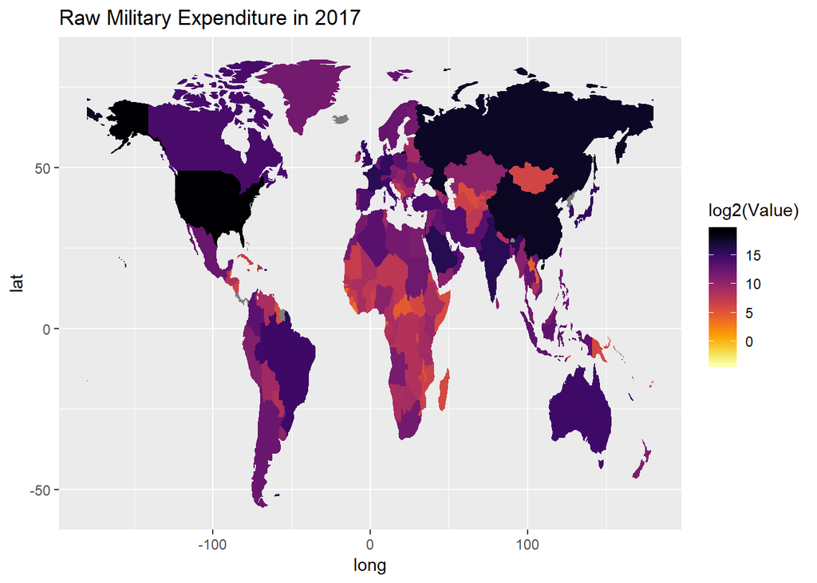

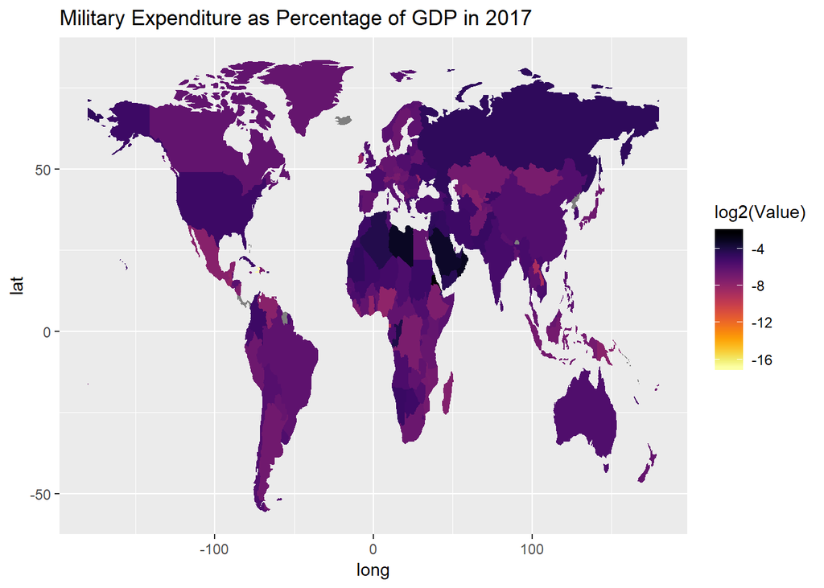

The darker the country the higher the value. Using these two maps, the strongest and weakest militaries by monetary value can be found.

### Strongest Militaries

1. USA
2. Russia
3. China
4. India
5. France

### Weakest Militaries

1. Ireland
2. Sierra Leone
3. Ghana
4. Latvia
5. Estonia

# Steps for Data Wrangling and Visualization

Having found the strongest and weakest militaries, it is now possible to answer both questions.

## Question 1

### How do the Strongest and Weakest Militaries Compare? Can we Conclude what Determines a Military’s Strength?

The information required to answer this question is best obtained through line graphs. Following are sets of graphs comparing the raw military expenditure and percentage of GDP for both sets of countries.

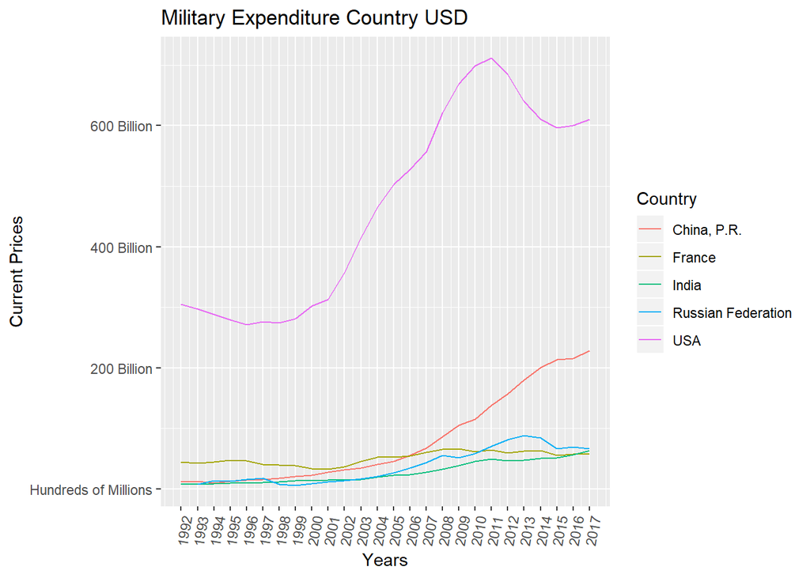

The United States is clearly the leader in raw military expenditure based off of this graph. The other countries are rather close to eachother, however, China is starting to leave the pack.

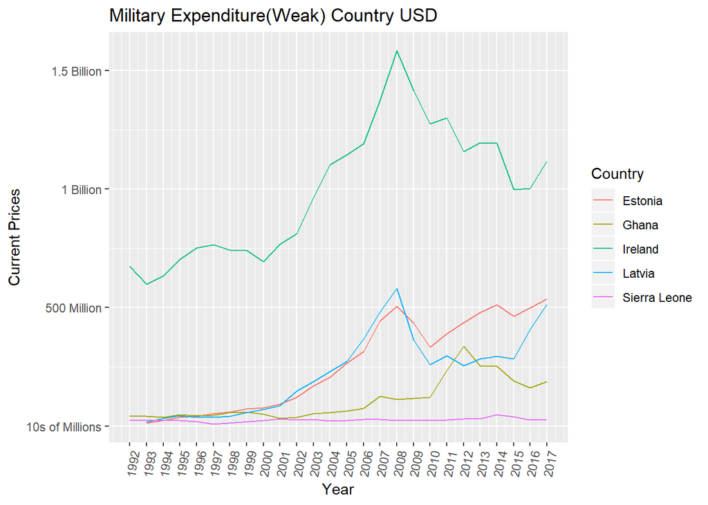

The weak countries have a similar looking plot. Here Ireland is the leader while the other four countries are all grouped together at the bottom. Latvia is currently on the rise and may head up to Ireland as time goes by.

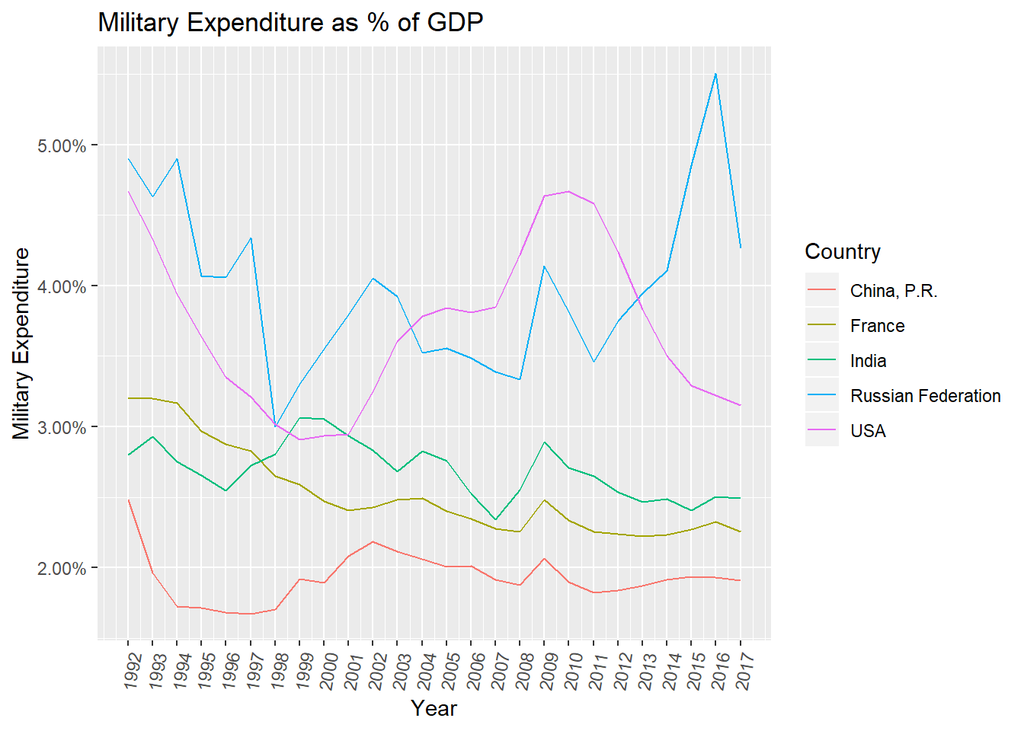

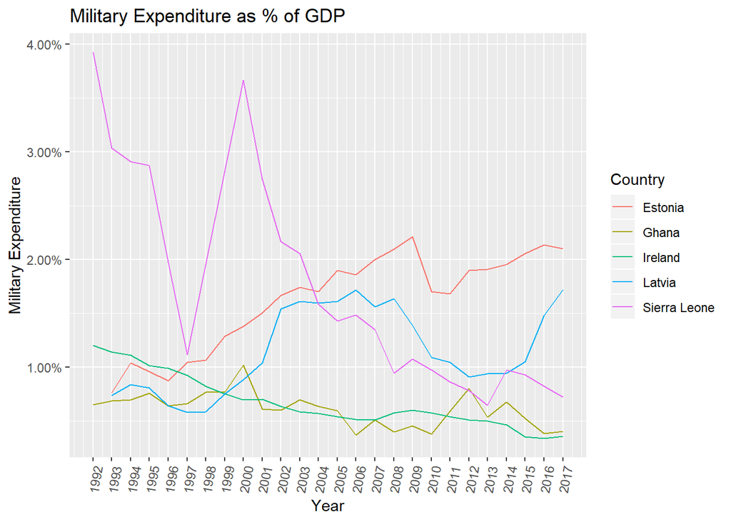

The top countries spend roughly 3% of their GDP on average on military while the bottom countries spend rougly 1%. It is important to take not that these countries have drastically different economies meaning that these percentages represent wildly different numbers. The difference between expenditure is truly huge.

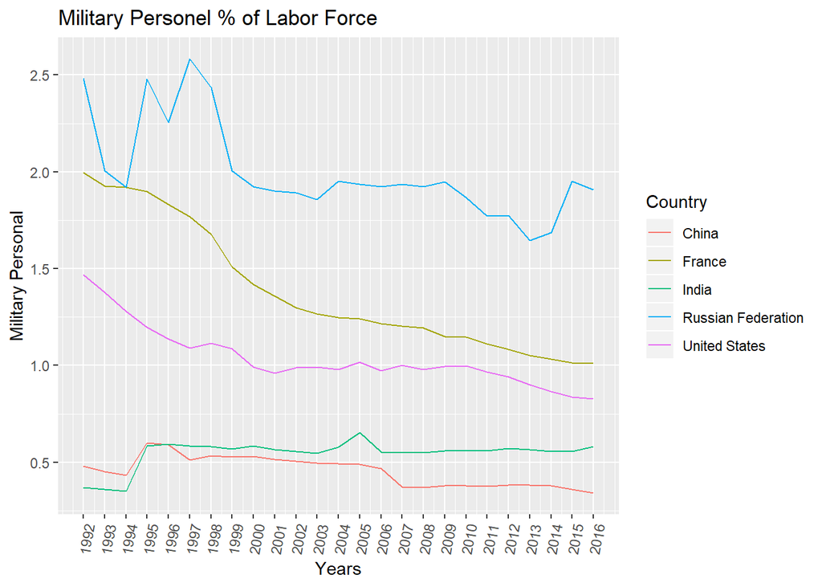

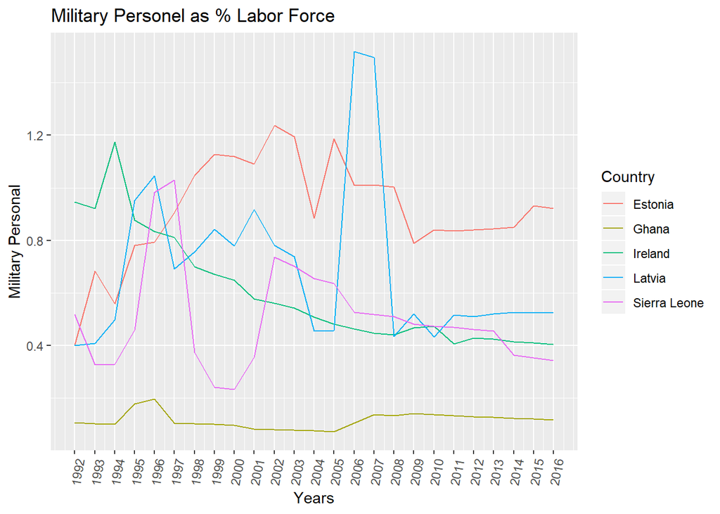

```
##    Country              ISO3           Total Aircraft Strength
##  Length:5           Length:5           Min.   : 1305
##  Class :character   Class :character   1st Qu.: 2102
##  Mode  :character   Mode  :character   Median : 2955
##                                        Mean   : 4784
##                                        3rd Qu.: 3794
##                                        Max.   :13762
##  Total Helicopter Strength  Combat Tanks   Armored Fighting Vehicles
##  Min.   : 610              Min.   :  406   Min.   : 4788
##  1st Qu.: 666              1st Qu.: 4426   1st Qu.: 6704
##  Median : 912              Median : 5884   Median : 6863
##  Mean   :1928              Mean   : 7478   Mean   :18143
##  3rd Qu.:1389              3rd Qu.: 6457   3rd Qu.:31298
##  Max.   :6065              Max.   :20216   Max.   :41062
##  Self-Propelled Artillery Total Naval Assets
##  Min.   : 290             Min.   :118.0
##  1st Qu.: 325             1st Qu.:295.0
##  Median :1710             Median :352.0
##  Mean   :2046             Mean   :378.8
##  3rd Qu.:1934             3rd Qu.:415.0
##  Max.   :5972             Max.   :714.0
```

```
##    Country              ISO3           Total Aircraft Strength
##  Length:4           Length:4           Min.   : 4.00
##  Class :character   Class :character   1st Qu.: 4.75
##  Mode  :character   Mode  :character   Median : 5.50
##                                        Mean   :10.00
##                                        3rd Qu.:10.75
##                                        Max.   :25.00
##  Total Helicopter Strength  Combat Tanks Armored Fighting Vehicles
##  Min.   : 4.00             Min.   :0.0   Min.   : 10.0
##  1st Qu.: 4.00             1st Qu.:0.0   1st Qu.:190.0
##  Median : 4.50             Median :0.0   Median :275.0
##  Mean   : 6.75             Mean   :0.5   Mean   :219.5
##  3rd Qu.: 7.25             3rd Qu.:0.5   3rd Qu.:304.5
##  Max.   :14.00             Max.   :2.0   Max.   :318.0
##  Self-Propelled Artillery Total Naval Assets
##  Min.   :0                Min.   : 6.0
##  1st Qu.:0                1st Qu.: 9.0
##  Median :0                Median :14.0
##  Mean   :0                Mean   :13.5
##  3rd Qu.:0                3rd Qu.:18.5
##  Max.   :0                Max.   :20.0
```

## Question 2

### How did the Cartels Affect Mexico’s Military?

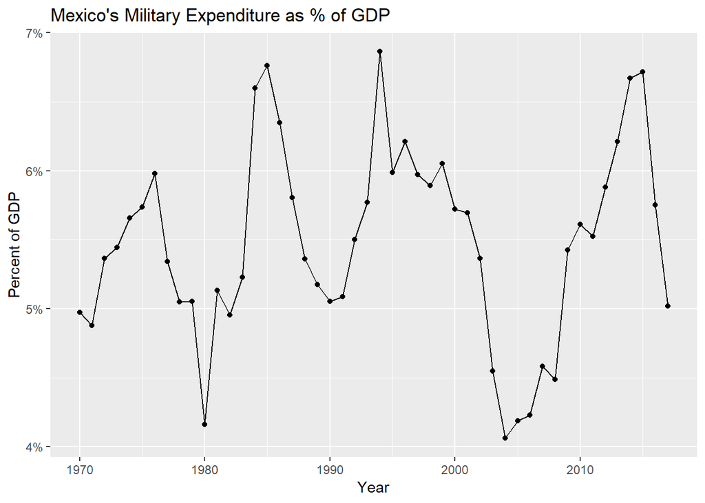

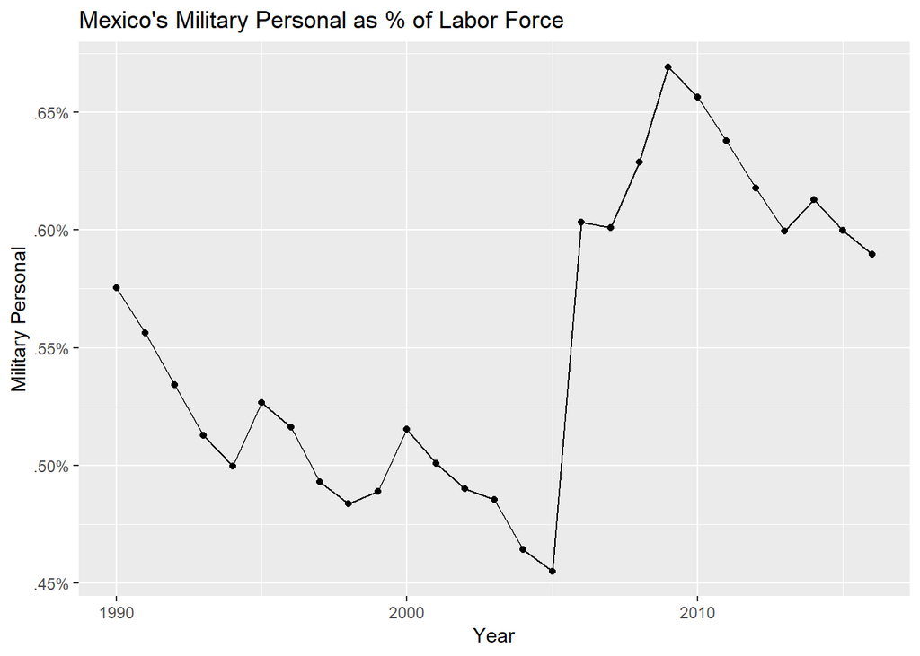

```
## # A tibble: 1 x 8
##   Country ISO3  `Total Aircraft~ `Total Helicopt~ `Combat Tanks`
##   <chr>   <chr>            <dbl>            <dbl>          <dbl>
## 1 Mexico  MEX                452              209              0
## # ... with 3 more variables: `Armored Fighting Vehicles` <dbl>,
## #   `Self-Propelled Artillery` <dbl>, `Total Naval Assets` <dbl>
```

```r
#animate(Animation)
```

```r
#animate(AnimationX)
```

# Answers to the Questions Raised

Now with the relevant information plotted out the questions can now be answered.

## Top Military Expenditure as % of GDP in 2017

1. Russia has taken the lead at ~4.25%
2. USA spends at ~3.2%
3. India spends at ~2.5%
4. France spends at ~2.3%
5. China spends at ~1.9%

## Bottom Military Expenditure as % of GDP in 2017

1. Estonia spends at ~2.1%
2. Latvia spends at ~1.75%
3. Sierra Leone spends at ~.75%
4. Ghana spends at ~.4%
5. Ireland spends at ~.35%

Taking into account the economy of each of these countries really puts their spending on military into perspective. The GDP difference between these two sets of countries is hundreds of billions.

Money is what sets these militaries apart. In 2017, the United States spent 600 billion on military while Ireland spent 1.1 billion. The monetary difference is absolutely staggering. For any of the bottom militaries to want to compete, they would need to have some sort of economic explosion.

## Question 2

### How did the Cartels Affect Mexico’s Military?

Military expenditure continued to increase rapidly until the year 2015. Not enough time has passed since then to draw any serious conclusions but using spending it appears that Mexico has given up on their war on drugs.

# Conclusion

Money and Military go hand in hand. This analysis really showed the difference between all countries throughout the years. In time we might see a new military superpower arrive and shake up the scene. Until then it appears that the United States, China, Russia, India, and France are going to be sitting at the top.

# Personal Contribution

## Andrew Maloney

Did the majority of the coding and plotting for the project. Acted as the project leader and set up group meetings and kept everyone on task. Driving force behind the project.

## Sonya Haan

Set up the presentation. Assisted with reviewing the rough drafts of all components of the project. Helped send the group in the right direction.

## Elaine Oldbear

Found supporting evidence for what was happening on graphs. Examined history and attatched conflicts and events to different graphical anomolies. Performed troubleshooting for the code.

## Connor Hergenreter

Wrote the projecet report and assisted in direction of the project. Helped with graphing ideas.

# Sources

Amadeo, K. (2019). Why Military Spending Is More Than You Think It Is. [online] The Balance. Available at: https://www.thebalance.com/u-s-military-budget-components-challenges-growth-3306320 [Accessed 6 May 2019].

Lakhani, N. (2019). Mexico’s war on drugs: what has it achieved and how is the US involved?. [online] the Guardian. Available at: https://www.theguardian.com/news/2016/dec/08/mexico-war-on-drugs-cost-achievements-us-billions [Accessed 6 May 2019].

## Datasets

Military Expenditure Data Sipri.org. (2019). SIPRI Military Expenditure Database | SIPRI. [online] Available at: https://www.sipri.org/databases/milex [Accessed 6 May 2019].

Arms Import Dataset Data.worldbank.org. (2019). Arms imports (SIPRI trend indicator values) | Data. [online] Available at: https://data.worldbank.org/indicator/MS.MIL.MPRT.KD [Accessed 6 May 2019].

Armed Forces Personel Dataset Data.worldbank.org. (2019). Armed forces personnel, total | Data. [online] Available at: https://data.worldbank.org/indicator/ms.mil.totl.p1 [Accessed 6 May 2019].

Global Firepower Dataset Kaggle.com. (2019). 2017 Military Strength Ranking. [online] Available at: https://www.kaggle.com/blitzr/gfp2017#GlobalFirePower_multiindex.csv [Accessed 6 May 2019].

## GGanimate

Robinson, David. “Gganimate v0.1.1.” Gganimate Package | R Documentation, 28 June 2018, www.rdocumentation.org/packages/gganimate/versions/0.1.1.